# Overlapping_pathway_DESeq2

#### Upregulated terms

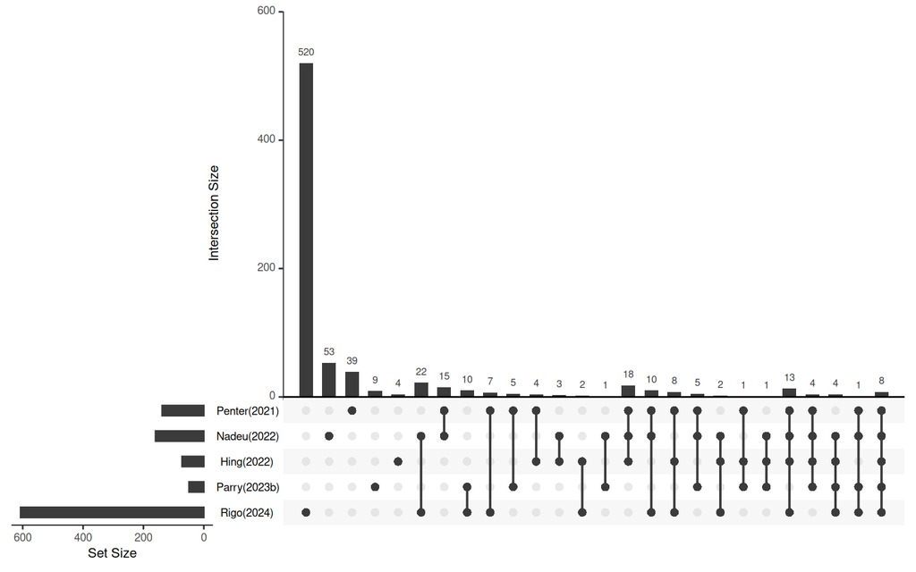

```r
# Extract adjusted significant upregulated GO:BP terms
sig_term.lst <- purrr::pmap(
  list(go_gsea.lst),
  function(gsea){
    selected_term <- gsea@result[gsea@result$NES > 0, "ID"]
    return(selected_term)
  }
)

# Reorder the list first
sig_term.lst <- sig_term.lst %>%
  purrr::discard(~ length(.x) == 0) %>%   # drop empty ones
  rev()                                   # reverse order

# Convert to UpSetR input
upset_data <- fromList(sig_term.lst)

# Plot UpSetR
upset(
  upset_data,
  sets = colnames(upset_data),      # ensures only these sets
  keep.order = TRUE,
  nintersects = NA
)
```

```r
# Find common GO:BP terms in all studies
five_common_go <- Reduce(intersect, sig_term.lst)
five_common_go
```

```
[1] "GOBP_OXIDATIVE_PHOSPHORYLATION"
[2] "GOBP_NUCLEOSIDE_PHOSPHATE_BIOSYNTHETIC_PROCESS"
[3] "GOBP_NUCLEOSIDE_TRIPHOSPHATE_METABOLIC_PROCESS"
[4] "GOBP_RIBOSE_PHOSPHATE_BIOSYNTHETIC_PROCESS"
[5] "GOBP_NUCLEOSIDE_TRIPHOSPHATE_BIOSYNTHETIC_PROCESS"
[6] "GOBP_SMALL_MOLECULE_CATABOLIC_PROCESS"
[7] "GOBP_MITOCHONDRIAL_TRANSPORT"
[8] "GOBP_CHROMOSOME_SEGREGATION"
```

```r
# Find common GO:BP terms in four studies: Penter, Nadeu, Parry, and Rigo
four_common_go <- Reduce(intersect, sig_term.lst[names(sig_term.lst) != "Hing(2022)"])
setdiff(four_common_go, five_common_go)
```

```
[1] "GOBP_ORGANIC_ACID_CATABOLIC_PROCESS"
```

```r
# Find common GO:BP terms in four studies: Nadeu, Hing, Parry, and Rigo
four_common_go <- Reduce(intersect, sig_term.lst[names(sig_term.lst) != "Penter(2021)"])
setdiff(four_common_go, five_common_go)
```

```
[1] "GOBP_MITOCHONDRION_ORGANIZATION"
[2] "GOBP_PURINE_CONTAINING_COMPOUND_METABOLIC_PROCESS"
[3] "GOBP_RIBOSE_PHOSPHATE_METABOLIC_PROCESS"
[4] "GOBP_SMALL_MOLECULE_BIOSYNTHETIC_PROCESS"
```

```r
# Find common GO:BP terms in four studies: Penter, Nadeu, Hing, and Rigo
four_common_go <- Reduce(intersect, sig_term.lst[names(sig_term.lst) != "Parry(2023b)"])
setdiff(four_common_go, five_common_go)
```

```
 [1] "GOBP_AEROBIC_RESPIRATION"
 [2] "GOBP_CELLULAR_RESPIRATION"
 [3] "GOBP_GENERATION_OF_PRECURSOR_METABOLITES_AND_ENERGY"
 [4] "GOBP_ATP_SYNTHESIS_COUPLED_ELECTRON_TRANSPORT"
 [5] "GOBP_ENERGY_DERIVATION_BY_OXIDATION_OF_ORGANIC_COMPOUNDS"
 [6] "GOBP_ELECTRON_TRANSPORT_CHAIN"
 [7] "GOBP_MITOCHONDRIAL_TRANSLATION"
 [8] "GOBP_ATP_METABOLIC_PROCESS"
 [9] "GOBP_MITOCHONDRIAL_GENE_EXPRESSION"
[10] "GOBP_MITOCHONDRIAL_RESPIRATORY_CHAIN_COMPLEX_ASSEMBLY"
[11] "GOBP_NADH_DEHYDROGENASE_COMPLEX_ASSEMBLY"
[12] "GOBP_MITOCHONDRIAL_MEMBRANE_ORGANIZATION"
[13] "GOBP_CYTOCHROME_COMPLEX_ASSEMBLY"
```

```r
# Find common GO:BP terms in four studies: Penter, Nadeu, Hing, and Parry
four_common_go <- Reduce(intersect, sig_term.lst[names(sig_term.lst) != "Rigo(2024)"])
setdiff(four_common_go, five_common_go)
```

```
[1] "GOBP_REGULATION_OF_MITOTIC_NUCLEAR_DIVISION"
[2] "GOBP_NUCLEAR_CHROMOSOME_SEGREGATION"
[3] "GOBP_MITOTIC_NUCLEAR_DIVISION"
[4] "GOBP_MITOTIC_SISTER_CHROMATID_SEGREGATION"
```

The common upregulated GO:BP terms were Consistent with the common upregulated hallmark terms that the both terms were associated with OXPHOS and nucleotide metabolism. indicating increased cell proliferation activity.

#### Downregulated terms

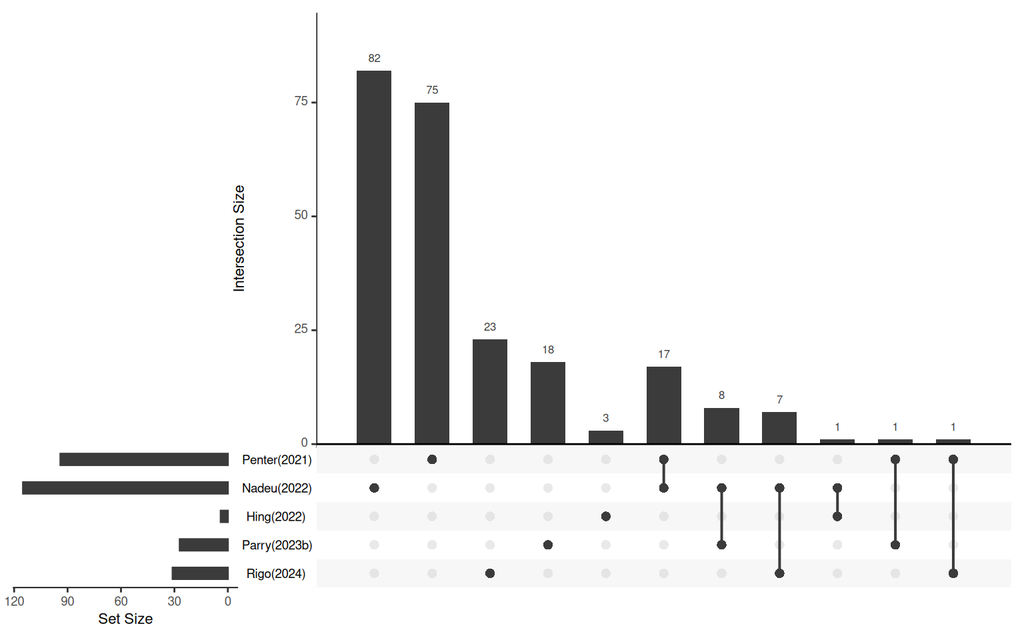

```r
# Extract adjusted significant downregulated GO:BP terms
sig_term.lst <- purrr::pmap(
  list(go_gsea.lst),
  function(gsea){
    selected_term <- gsea@result[gsea@result$NES < 0, "ID"]
    return(selected_term)
  }
)

# Reorder the list first
sig_term.lst <- sig_term.lst %>%
  purrr::discard(~ length(.x) == 0) %>%   # drop empty ones
  rev()                                   # reverse order

# Convert to UpSetR input
upset_data <- fromList(sig_term.lst)

# Plot UpSetR
upset(
  upset_data,
  sets = colnames(upset_data),      # ensures only these sets
  keep.order = TRUE,
  nintersects = NA
)
```

Overall, no common downregulated GO:BP terms in all studies were detected. We will idenity common terms in two studies.

```r
# Common terms between Penter and Rigo
Reduce(intersect, sig_term.lst[c("Penter(2021)", "Rigo(2024)")])
```

```
[1] "GOBP_CONNECTIVE_TISSUE_DEVELOPMENT"
```

```r
# Common terms between Penter and Parry
Reduce(intersect, sig_term.lst[c("Penter(2021)", "Parry(2023b)")])
```

```
[1] "GOBP_HUMORAL_IMMUNE_RESPONSE_MEDIATED_BY_CIRCULATING_IMMUNOGLOBULIN"
```

```r
# Common terms between Nadeu and Hing
Reduce(intersect, sig_term.lst[c("Nadeu(2022)", "Hing(2022)")])
```

```
[1] "GOBP_POSITIVE_REGULATION_OF_MRNA_CATABOLIC_PROCESS"
```

```r
# Common terms between Nadeu and Rigo
Reduce(intersect, sig_term.lst[c("Nadeu(2022)", "Rigo(2024)")])
```

```
[1] "GOBP_REGULATION_OF_TRANSMEMBRANE_RECEPTOR_PROTEIN_SERINE_THREONINE_KINASE_SIGNALING_PATHWAY"
[2] "GOBP_NEGATIVE_REGULATION_OF_TRANSMEMBRANE_RECEPTOR_PROTEIN_SERINE_THREONINE_KINASE_SIGNALING_PATHWAY"
[3] "GOBP_REGULATION_OF_CELLULAR_RESPONSE_TO_GROWTH_FACTOR_STIMULUS"
[4] "GOBP_SKELETAL_SYSTEM_DEVELOPMENT"
[5] "GOBP_NEGATIVE_REGULATION_OF_TRANSFORMING_GROWTH_FACTOR_BETA_RECEPTOR_SIGNALING_PATHWAY"
[6] "GOBP_SKELETAL_SYSTEM_MORPHOGENESIS"
[7] "GOBP_CHONDROCYTE_DIFFERENTIATION"
```

```r
# Common terms between Nadeu and Parry
Reduce(intersect, sig_term.lst[c("Nadeu(2022)", "Parry(2023b)")])
```

```
[1] "GOBP_MRNA_PROCESSING"
[2] "GOBP_RNA_SPLICING"
[3] "GOBP_REGULATION_OF_MRNA_PROCESSING"
[4] "GOBP_RNA_SPLICING_VIA_TRANSESTERIFICATION_REACTIONS"
[5] "GOBP_POSITIVE_REGULATION_OF_DNA_TEMPLATED_TRANSCRIPTION_ELONGATION"
[6] "GOBP_REGULATION_OF_DNA_TEMPLATED_TRANSCRIPTION_ELONGATION"
[7] "GOBP_DNA_TEMPLATED_TRANSCRIPTION_ELONGATION"
[8] "GOBP_POSITIVE_REGULATION_OF_TRANSCRIPTION_ELONGATION_BY_RNA_POLYMERASE_II"
```

```r
# Common terms between Penter and Nadeu
Reduce(intersect, sig_term.lst[c("Penter(2021)", "Nadeu(2022)")])
```

```
 [1] "GOBP_ALPHA_BETA_T_CELL_DIFFERENTIATION"
 [2] "GOBP_LYMPHOCYTE_DIFFERENTIATION"
 [3] "GOBP_T_CELL_DIFFERENTIATION"
 [4] "GOBP_CD4_POSITIVE_ALPHA_BETA_T_CELL_DIFFERENTIATION"
 [5] "GOBP_ALPHA_BETA_T_CELL_ACTIVATION"
 [6] "GOBP_MONONUCLEAR_CELL_DIFFERENTIATION"
 [7] "GOBP_LEUKOCYTE_DIFFERENTIATION"
 [8] "GOBP_CD4_POSITIVE_ALPHA_BETA_T_CELL_ACTIVATION"
 [9] "GOBP_TISSUE_REGENERATION"
[10] "GOBP_T_CELL_DIFFERENTIATION_INVOLVED_IN_IMMUNE_RESPONSE"
[11] "GOBP_REGULATION_OF_HEMOPOIESIS"
[12] "GOBP_T_CELL_ACTIVATION"
[13] "GOBP_DEVELOPMENTAL_GROWTH"
[14] "GOBP_RESPONSE_TO_TRANSFORMING_GROWTH_FACTOR_BETA"
[15] "GOBP_IMMUNE_RESPONSE_REGULATING_CELL_SURFACE_RECEPTOR_SIGNALING_PATHWAY"
[16] "GOBP_NEGATIVE_REGULATION_OF_CELL_DIFFERENTIATION"
[17] "GOBP_POSITIVE_REGULATION_OF_LOCOMOTION"
```

### KEGG pathways

```r
# Import the results from all studies and collect in a list
path_to_download <- str_c(path_to_single_cell_analysis, "/", study.lst, "/pseudo_bulk_deseq2/", study_names, "_deseq2_kegg_gsea.rds")
path_to_download <- path_to_download
kegg_gsea.lst <- purrr::pmap(
  list(path_to_download),
  function(path){
    gsea <- readRDS(path)
    return(gsea)
  }
)
names(kegg_gsea.lst) <- names.lst
```

#### Upregulated terms

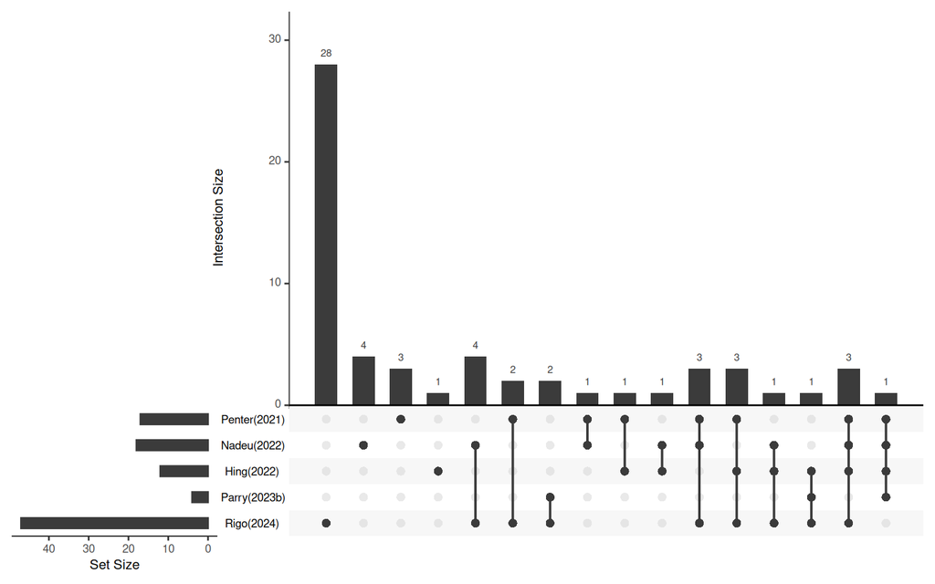

```r
# Extract adjusted significant upregulated KEGG terms
sig_term.lst <- purrr::pmap(
  list(kegg_gsea.lst),
  function(gsea){
    selected_term <- gsea@result[gsea@result$NES > 0, "ID"]
    return(selected_term)
  }
)

# Reorder the list first
sig_term.lst <- sig_term.lst %>%
  purrr::discard(~ length(.x) == 0) %>%   # drop empty ones
  rev()                                   # reverse order

# Convert to UpSetR input
upset_data <- fromList(sig_term.lst)

# Plot UpSetR
upset(
  upset_data,
  sets = colnames(upset_data),      # ensures only these sets
  keep.order = TRUE,
  nintersects = NA
)
```

Although no common terms in all five studies were detected, we will identify common terms in four studies.

```r
# Common KEGG terms in four studies: Penter, Nadeu, Hing, and Parry
Reduce(intersect, sig_term.lst[c("Penter(2021)", "Nadeu(2022)", "Hing(2022)", "Parry(2023b)")])
```

```
[1] "KEGG_PYRIMIDINE_METABOLISM"
```

```r
# Common KEGG terms in four studies: Penter, Nadeu, Hing, and Rigo
Reduce(intersect, sig_term.lst[c("Penter(2021)", "Nadeu(2022)", "Hing(2022)", "Rigo(2024)")])
```

```
[1] "KEGG_OXIDATIVE_PHOSPHORYLATION" "KEGG_HUNTINGTONS_DISEASE"
[3] "KEGG_PURINE_METABOLISM"
```

Generally, the common upregulated KEGG terms were related to OXPHOS and nucleotide metabolisms, consistent with hallmark and GO:BP upregulated terms.

#### Downregulated terms

As no significant downregulated KEGG terms in Rigo(2024) are detected, we will not show it.

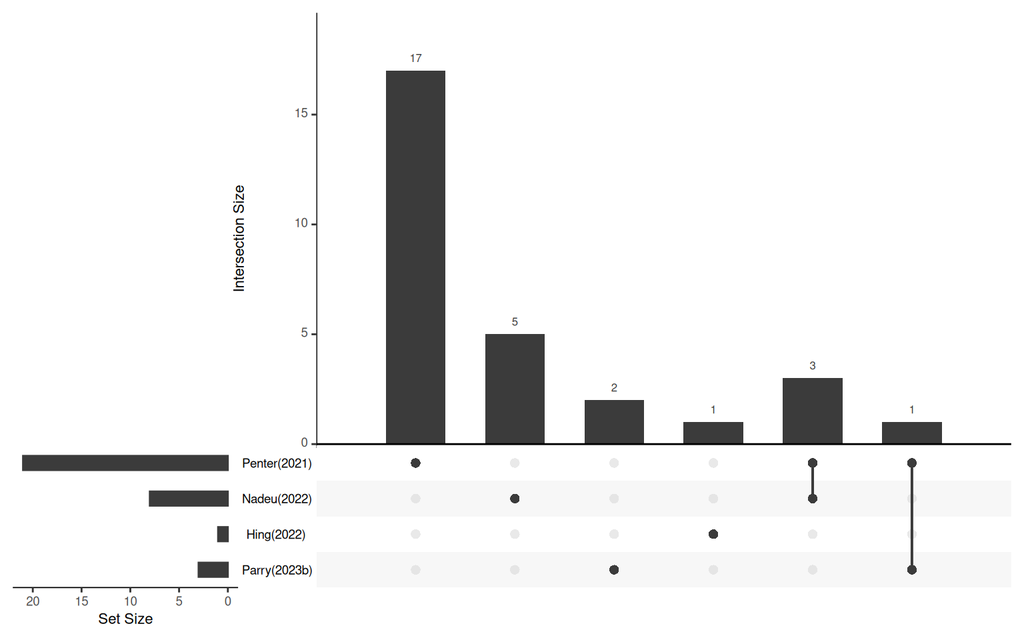

```r
# Extract adjusted significant downregulated KEGG terms
sig_term.lst <- purrr::pmap(
  list(kegg_gsea.lst),
  function(gsea){
    selected_term <- gsea@result[gsea@result$NES < 0, "ID"]
    return(selected_term)
  }
)

# Reorder the list first
sig_term.lst <- sig_term.lst %>%
  purrr::discard(~ length(.x) == 0) %>%   # drop empty ones
  rev()                                   # reverse order

# Convert to UpSetR input
upset_data <- fromList(sig_term.lst)

# Plot UpSetR
upset(
  upset_data,
  sets = colnames(upset_data),      # ensures only these sets
  keep.order = TRUE,
  nintersects = NA
)
```

No common terms are detected. We will identify common terms in two studies.

```r
# Common terms between Penter and Parry
Reduce(intersect, sig_term.lst[c("Penter(2021)", "Parry(2023b)")])
```

```
[1] "KEGG_TOLL_LIKE_RECEPTOR_SIGNALING_PATHWAY"
```

```r
# Common terms between Penter and Nadeu
Reduce(intersect, sig_term.lst[c("Penter(2021)", "Nadeu(2022)")])
```

```
[1] "KEGG_REGULATION_OF_ACTIN_CYTOSKELETON"
[2] "KEGG_MAPK_SIGNALING_PATHWAY"
[3] "KEGG_NEUROTROPHIN_SIGNALING_PATHWAY"
```

### Reactome pathways

```r
# Import the results from all studies and collect in a list
path_to_download <- str_c(path_to_single_cell_analysis, "/", study.lst, "/pseudo_bulk_deseq2/", study_names, "_deseq2_reactome_gsea.rds")
path_to_download <- path_to_download
reactome_gsea.lst <- purrr::pmap(
  list(path_to_download),
  function(path){
    gsea <- readRDS(path)
    return(gsea)
  }
)
names(reactome_gsea.lst) <- names.lst
```

#### Upregulated terms

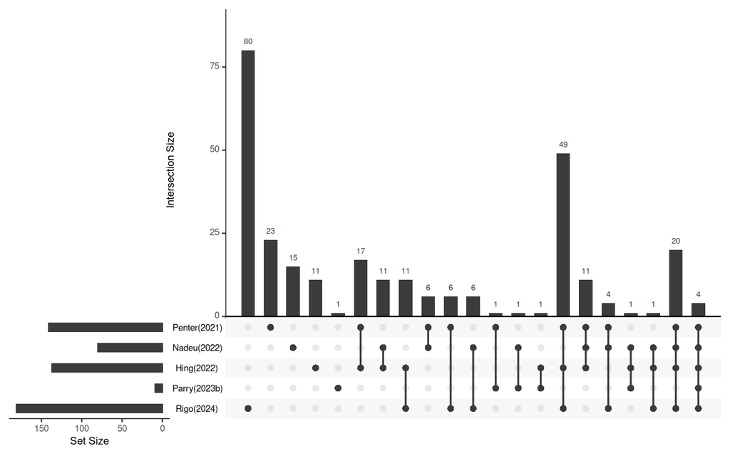

```r
# Extract adjusted significant upregulated Reactome terms
sig_term.lst <- purrr::pmap(
  list(reactome_gsea.lst),
  function(gsea){
    selected_term <- gsea@result[gsea@result$NES > 0, "ID"]
    return(selected_term)
  }
)

# Reorder the list first
sig_term.lst <- sig_term.lst %>%
  purrr::discard(~ length(.x) == 0) %>%   # drop empty ones
  rev()                                   # reverse order

# Convert to UpSetR input
upset_data <- fromList(sig_term.lst)

# Plot UpSetR
upset(
  upset_data,
  sets = colnames(upset_data),      # ensures only these sets
  keep.order = TRUE,
  nintersects = NA
)
```

```r
# Common upregulated reactome terms in all studies
five_common_reactome <- Reduce(intersect, sig_term.lst)
five_common_reactome
```

```
[1] "REACTOME_MITOCHONDRIAL_TRANSLATION"
[2] "REACTOME_MITOCHONDRIAL_PROTEIN_IMPORT"
[3] "REACTOME_CELL_CYCLE_CHECKPOINTS"
[4] "REACTOME_METABOLISM_OF_NUCLEOTIDES"
```

```r
# Common upregulated reactome terms in four studies
four_common_reactome <- Reduce(intersect, sig_term.lst[names(sig_term.lst) != "Parry(2023b)"])
setdiff(four_common_reactome, five_common_reactome)
```

```
 [1] "REACTOME_AEROBIC_RESPIRATION_AND_RESPIRATORY_ELECTRON_TRANSPORT"
 [2] "REACTOME_RESPIRATORY_ELECTRON_TRANSPORT"
 [3] "REACTOME_PROTEIN_LOCALIZATION"
 [4] "REACTOME_TRANSLATION"
 [5] "REACTOME_APC_C_MEDIATED_DEGRADATION_OF_CELL_CYCLE_PROTEINS"
 [6] "REACTOME_MITOTIC_G1_PHASE_AND_G1_S_TRANSITION"
 [7] "REACTOME_APC_C_CDH1_MEDIATED_DEGRADATION_OF_CDC20_AND_OTHER_APC_C_CDH1_TARGETED_PROTEINS_IN_LATE_MITOSIS_EARLY_G1"
 [8] "REACTOME_ORC1_REMOVAL_FROM_CHROMATIN"
 [9] "REACTOME_SWITCHING_OF_ORIGINS_TO_A_POST_REPLICATIVE_STATE"
[10] "REACTOME_DNA_REPLICATION_PRE_INITIATION"
[11] "REACTOME_MITOCHONDRIAL_PROTEIN_DEGRADATION"
[12] "REACTOME_DNA_REPLICATION"
[13] "REACTOME_COMPLEX_I_BIOGENESIS"
[14] "REACTOME_METABOLISM_OF_AMINO_ACIDS_AND_DERIVATIVES"
[15] "REACTOME_SYNTHESIS_OF_DNA"
[16] "REACTOME_S_PHASE"
[17] "REACTOME_G2_M_CHECKPOINTS"
[18] "REACTOME_MITOTIC_METAPHASE_AND_ANAPHASE"
[19] "REACTOME_SEPARATION_OF_SISTER_CHROMATIDS"
[20] "REACTOME_METABOLISM_OF_VITAMINS_AND_COFACTORS"
```

Overall, the upregulated reactome terms were consistent with previous upregulated terms which were related to OXPHOS, nucleotide metabolisms, cell cycle, and cell proliferation.

#### Downregulated terms

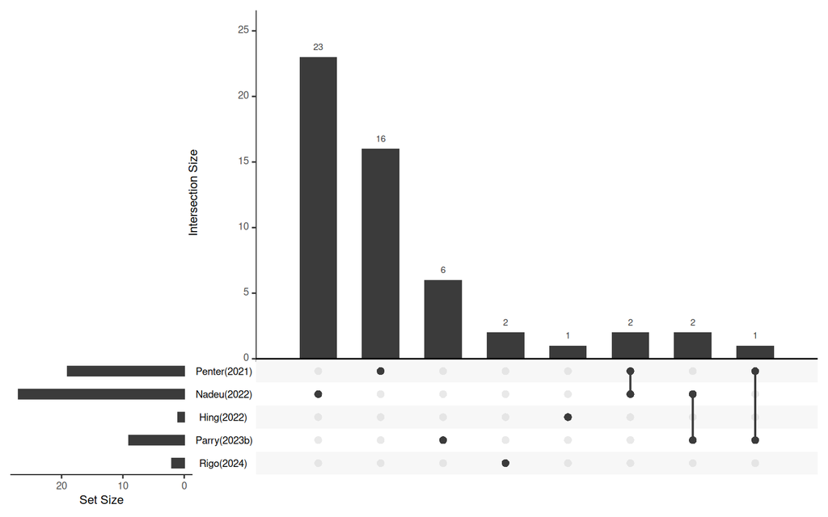

```r
# Extract adjusted significant downregulated Reactome terms
sig_term.lst <- purrr::pmap(
  list(reactome_gsea.lst),
  function(gsea){
    selected_term <- gsea@result[gsea@result$NES < 0, "ID"]
    return(selected_term)
  }
)

# Reorder the list first
sig_term.lst <- sig_term.lst %>%
  purrr::discard(~ length(.x) == 0) %>%   # drop empty ones
  rev()                                   # reverse order

# Convert to UpSetR input
upset_data <- fromList(sig_term.lst)

# Plot UpSetR
upset(
  upset_data,
  sets = colnames(upset_data),      # ensures only these sets
  keep.order = TRUE,
  nintersects = NA
)
```

No common terms are detected. We will identify common terms in two studies.

```r
# Common terms between Penter and Parry
Reduce(intersect, sig_term.lst[c("Penter(2021)", "Parry(2023b)")])
```

```
[1] "REACTOME_TOLL_LIKE_RECEPTOR_CASCADES"
```

```r
# Common terms between Nadeu and Parry
Reduce(intersect, sig_term.lst[c("Nadeu(2022)", "Parry(2023b)")])
```

```
[1] "REACTOME_PROCESSING_OF_CAPPED_INTRON_CONTAINING_PRE_MRNA"
[2] "REACTOME_SARS_COV_2_ACTIVATES_MODULATES_INNATE_AND_ADAPTIVE_IMMUNE_RESPONSES"
```

```r
# Common terms between Penter and Nadeu
Reduce(intersect, sig_term.lst[c("Penter(2021)", "Nadeu(2022)")])
```

```
[1] "REACTOME_SIGNALING_BY_TGFB_FAMILY_MEMBERS"
[2] "REACTOME_TRANSCRIPTIONAL_REGULATION_OF_WHITE_ADIPOCYTE_DIFFERENTIATION"
```